# maierucsb

Mitchell Maier

January 19, 2016

## **Content**

I am interested in reducing waste and inefficient products that create environmental and toxilogical harm. I am also interested in GIS and visualizing geographic data in useful and interesting ways (*especially data related to global deforestation right now as it is a large component of my thesis project*)

In this class I will be looking into pollution statistics… [see my group site here](https://github.com/pollute/pollute.github.io)

## **Techniques**

I think collaborative model building and interactive plots and maps will be very useful for my project now and research in the future.

## **Data**

For now, in the name of practice, I’ll illustrate some data on how far Derrick Rose, point gaurd for the Chicago Bulls who has been horrendously riddled by knee injuries, has fallen statistically from his great 2010-2011 campaign.

Here is his shot chart from 2010-2011

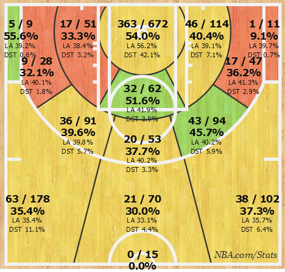

Here is his shot chart so far from 2015-2016

[figure not shown]

As can be seen, Derrick Rose’s statistical climb has regressed… This decline can aslo be seen in his overall [stats](http://stats.nba.com/player/#!/201565/)… The future looks tragically quite dim for the former MVP.

[output not shown]

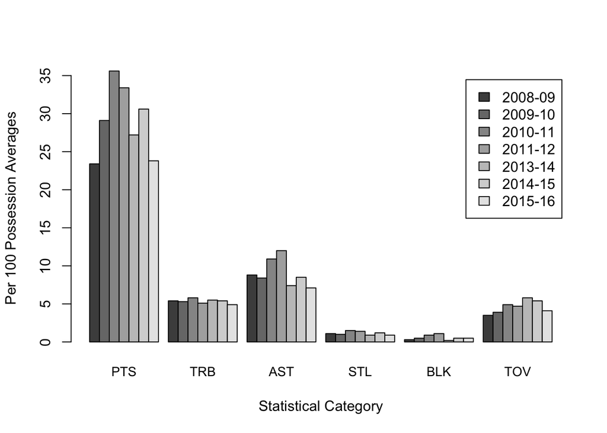

## Assignment4

wide to long format of emmissions

| Country | year | emissions |
| --- | --- | --- |
| Afghanistan | 1970.000000 | 1814 |
| Albania | 1970.000000 | 4435 |
| Algeria | 1970.000000 | 18851 |

top five emitting countries in 2014

| Country | Year | Emissions |
| --- | --- | --- |
| China | 2014 | 10540750 |
| United States of America | 2014 | 5334530 |
| India | 2014 | 2341897 |
| Russian Federation | 2014 | 1766427 |
| Japan | 2014 | 1278922 |

top five emitting countries from 1970-2014

| Country | Total Emissions |
| --- | --- |
| United States of America | 231948899 |
| China | 174045927 |
| Russian Federation | 81242427 |
| Japan | 51276329 |
| Germany | 43382205 |